# Предсказания оттока клиентов

## Описание исследования

Из «Бета-Банка» стали уходить клиенты. Каждый месяц. Немного, но заметно. Банковские маркетологи посчитали: сохранять текущих клиентов дешевле, чем привлекать новых. Нужно спрогнозировать, уйдёт клиент из банка в ближайшее время или нет. Вам предоставлены исторические данные о поведении клиентов и расторжении договоров с банком.

## Содержание

1. Изучение общей информации
2. Предобработка данных
3. Выяление и устранение дисбаланса классов
4. Обучение и выбор лучшей модели
5. Общий вывод

## Шаг 0. Импорт необходимых библиотек

```python
import pandas as pd
import numpy as np
from sklearn.preprocessing import StandardScaler
from sklearn.metrics import roc_auc_score, roc_curve, f1_score, accuracy_score
from sklearn.model_selection import train_test_split, GridSearchCV
from sklearn.linear_model import LogisticRegression
from sklearn.ensemble import RandomForestClassifier
import matplotlib.pyplot as plt
from sklearn.utils import shuffle
```

## Шаг 1. Изучение общей информации

```python
churn_data = pd.read_csv('ds_/datasets/Churn.csv')
churn_data.info()
print()
churn_data.head()
```

```
<class 'pandas.core.frame.DataFrame'>
RangeIndex: 10000 entries, 0 to 9999
Data columns (total 14 columns):
 #   Column           Non-Null Count  Dtype
---  ------           --------------  -----
 0   RowNumber        10000 non-null  int64
 1   CustomerId       10000 non-null  int64
 2   Surname          10000 non-null  object
 3   CreditScore      10000 non-null  int64
 4   Geography        10000 non-null  object
 5   Gender           10000 non-null  object
 6   Age              10000 non-null  int64
 7   Tenure           9091 non-null   float64
 8   Balance          10000 non-null  float64
 9   NumOfProducts    10000 non-null  int64
 10  HasCrCard        10000 non-null  int64
 11  IsActiveMember   10000 non-null  int64
 12  EstimatedSalary  10000 non-null  float64
 13  Exited           10000 non-null  int64
dtypes: float64(3), int64(8), object(3)
memory usage: 1.1+ MB
```

|  | RowNumber | CustomerId | Surname | CreditScore | Geography | Gender | Age | Tenure | Balance | NumOfProducts | HasCrCard | IsActiveMember | EstimatedSalary | Exited |
| --- | --- | --- | --- | --- | --- | --- | --- | --- | --- | --- | --- | --- | --- | --- |
| 0 | 1 | 15634602 | Hargrave | 619 | France | Female | 42 | 2.0 | 0.00 | 1 | 1 | 1 | 101348.88 | 1 |
| 1 | 2 | 15647311 | Hill | 608 | Spain | Female | 41 | 1.0 | 83807.86 | 1 | 0 | 1 | 112542.58 | 0 |
| 2 | 3 | 15619304 | Onio | 502 | France | Female | 42 | 8.0 | 159660.80 | 3 | 1 | 0 | 113931.57 | 1 |
| 3 | 4 | 15701354 | Boni | 699 | France | Female | 39 | 1.0 | 0.00 | 2 | 0 | 0 | 93826.63 | 0 |
| 4 | 5 | 15737888 | Mitchell | 850 | Spain | Female | 43 | 2.0 | 125510.82 | 1 | 1 | 1 | 79084.10 | 0 |

## Шаг 2. Предобрабока

```python
# удалим ненужный столбец - row_number и surname, протому что при OHE кодировке мы не сможем закодировать качесвтенно столбец с фамилиями
churn_data.drop(['RowNumber','Surname','CustomerId'],inplace=True,axis=1)
```

```python
# поменяем названия
churn_data.set_axis(['credit_score','geography','gender','age','tenure','balance','num_of_products','has_cr_card','is_active_member','estimated_salary','exited'],inplace=True,axis=1)
churn_data.head()
```

|  | credit_score | geography | gender | age | tenure | balance | num_of_products | has_cr_card | is_active_member | estimated_salary | exited |
| --- | --- | --- | --- | --- | --- | --- | --- | --- | --- | --- | --- |
| 0 | 619 | France | Female | 42 | 2.0 | 0.00 | 1 | 1 | 1 | 101348.88 | 1 |
| 1 | 608 | Spain | Female | 41 | 1.0 | 83807.86 | 1 | 0 | 1 | 112542.58 | 0 |
| 2 | 502 | France | Female | 42 | 8.0 | 159660.80 | 3 | 1 | 0 | 113931.57 | 1 |
| 3 | 699 | France | Female | 39 | 1.0 | 0.00 | 2 | 0 | 0 | 93826.63 | 0 |
| 4 | 850 | Spain | Female | 43 | 2.0 | 125510.82 | 1 | 1 | 1 | 79084.10 | 0 |

```python
churn_data['tenure'].isna().sum()
```

```
909
```

```python
# заменим NaN на нулевые значения
churn_data['tenure'].fillna(0,inplace=True);
```

```python
# все столбцы с категориальными переменными закодируем кодировкой OHE
churn_data_ohe = pd.get_dummies(churn_data, drop_first=True)
churn_data_ohe.head()
```

|  | credit_score | age | tenure | balance | num_of_products | has_cr_card | is_active_member | estimated_salary | exited | geography_Germany | geography_Spain | gender_Male |
| --- | --- | --- | --- | --- | --- | --- | --- | --- | --- | --- | --- | --- |
| 0 | 619 | 42 | 2.0 | 0.00 | 1 | 1 | 1 | 101348.88 | 1 | 0 | 0 | 0 |
| 1 | 608 | 41 | 1.0 | 83807.86 | 1 | 0 | 1 | 112542.58 | 0 | 0 | 1 | 0 |
| 2 | 502 | 42 | 8.0 | 159660.80 | 3 | 1 | 0 | 113931.57 | 1 | 0 | 0 | 0 |
| 3 | 699 | 39 | 1.0 | 0.00 | 2 | 0 | 0 | 93826.63 | 0 | 0 | 0 | 0 |
| 4 | 850 | 43 | 2.0 | 125510.82 | 1 | 1 | 1 | 79084.10 | 0 | 0 | 1 | 0 |

```python
churn_data['tenure'].isna().sum()
```

```
0
```

### Вывод

Исследование данных показало,что были нулевые значения в столбце `tenure`, поэтому они были заменены на нулевые значения,помимо этого столбцы были переименованы для удобства. Все столбцы,содержащие категориальные переменные были закодированы техникой OHE

## Шаг 3. Исследование баланса классов

```python
features = churn_data_ohe.drop(['exited'],axis=1)
target = churn_data_ohe['exited']
```

```python
target_class = target.value_counts()
target_class
```

```
0    7963
1    2037
Name: exited, dtype: int64
```

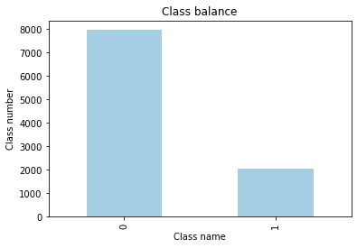

```python
target_class.plot(kind='bar',colormap='Paired')
plt.xlabel('Class name')
plt.ylabel('Class number')
plt.title('Class balance')
plt.show();
```

```python
# обучим лес с подобранными параметрами до исправления дисбланса классов

# разделим выборку на обучающую и валидационную
features_train, features_valid, target_train, target_valid = train_test_split(features,target,test_size=0.25,random_state=12345)


forest = RandomForestClassifier(max_depth=13, n_estimators=100)
forest.fit(features_train,target_train)

predictions_valid = forest.predict(features_valid)

print('F1 мера:',f1_score(predictions_valid,target_valid))
print('ROC_AUC:',roc_auc_score(predictions_valid,target_valid))
print('Accuracy:',accuracy_score(predictions_valid,target_valid))
```

```
F1 мера: 0.5555555555555556
ROC_AUC: 0.8233931440607066
Accuracy: 0.8528
```

### Вывод

При дисбалансе очень сильно проседает метрика `f1`,поэтому лучше разобраться с дисбалансом и улучшить метрики по максимуму

```python
def upsampling(features,target,repeat):
    features_zeros = features[target == 0]
    features_ones = features[target == 1]

    target_zeros = target[target == 0]
    target_ones = target[target == 1]

    features_upsampled = pd.concat([features_zeros] + [features_ones] * repeat)
    target_upsampled = pd.concat([target_zeros] + [target_ones] * repeat)

    features_upsampled, target_upsampled = shuffle(features_upsampled, target_upsampled, random_state=12345)

    return features_upsampled, target_upsampled
```

```python
features, target = upsampling(features,target,4)
```

```python
# стандартизируем данные
scaler = StandardScaler()
scaler.fit(features)
features = pd.DataFrame(scaler.transform(features))
```

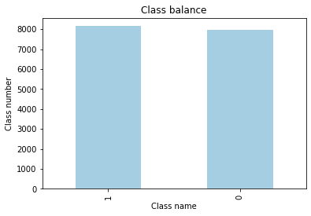

```python
target.value_counts().plot(kind='bar',colormap='Paired')
plt.xlabel('Class name')
plt.ylabel('Class number')
plt.title('Class balance')
plt.show();
```

### Вывод

Мы с помощью `upsampling` избавились от явного дисбаланса классов( класс `0` преобладал над классом `1` ),помимо этого все признаки были стандартизированы,в общем данные готовы к обучению.

## Шаг 4. Обучение моделей и выбор лучшей

```python
# разделим выборку на обучающую и валидационную
features_train, features_valid, target_train, target_valid = train_test_split(features,target,test_size=0.25,random_state=12345)
```

### Рандомный лес

```python
# используем модель GridSearchCV для автоподбора наилучших гиперпараметров нашей модели

# инициализируем модель леса
forest = RandomForestClassifier()
```

```python
# инициализируем возможные параметры
parametrs = { 'n_estimators': range (10, 101, 10),
              'max_depth': range (1,15, 2) }
```

```python
%%time
#обучим grid_search_cv
grid = GridSearchCV(forest, parametrs, cv=3)
grid.fit(features_train, target_train);
```

```
CPU times: user 1min 18s, sys: 818 ms, total: 1min 18s
Wall time: 1min 20s
```

```
GridSearchCV(cv=3, estimator=RandomForestClassifier(),
             param_grid={'max_depth': range(1, 15, 2),
                         'n_estimators': range(10, 101, 10)})
```

```python
grid.best_params_
```

```
{'max_depth': 13, 'n_estimators': 70}
```

```python
# переопределим лес и посчитаем необходимые метрики
forest = RandomForestClassifier(max_depth=13, n_estimators=100)
forest.fit(features_train,target_train)

predictions_valid = forest.predict(features_valid)

print('F1 мера:',f1_score(predictions_valid,target_valid))
print('ROC_AUC:',roc_auc_score(predictions_valid,target_valid))
print('Accuracy:',accuracy_score(predictions_valid,target_valid))
```

```
F1 мера: 0.9181327703495191
ROC_AUC: 0.9166641972511047
Accuracy: 0.913356504468719
```

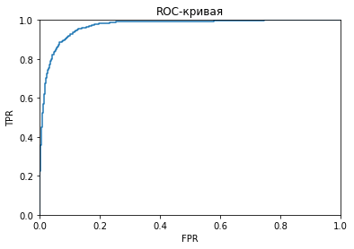

```python
# построим roc-кривую
probabilities = forest.predict_proba(features_valid)[:, 1]
fpr, tpr, thresholds = roc_curve(target_valid, probabilities)

plt.figure()
plt.plot(fpr, tpr)
plt.xlim([0.0, 1.0])
plt.ylim([0.0, 1.0])
plt.xlabel('FPR')
plt.ylabel('TPR')
plt.title('ROC-кривая')
plt.show()
```

### Стоит проверить еще логистическую регрессию

```python
logreg = LogisticRegression(random_state=12345)
logreg.fit(features_train,target_train);
```

```python
lr_predictions_valid = logreg.predict(features_valid)

print('F1 мера:',f1_score(lr_predictions_valid,target_valid))
print('ROC_AUC:',roc_auc_score(lr_predictions_valid,target_valid))
print('Accuracy:',accuracy_score(lr_predictions_valid,target_valid))
```

```
F1 мера: 0.7118727050183599
ROC_AUC: 0.7077261274162796
Accuracy: 0.7077954319761668
```

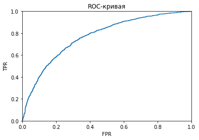

```python
lr_probabilities = logreg.predict_proba(features_valid)[:, 1]
fpr, tpr, thresholds = roc_curve(target_valid, lr_probabilities)

plt.figure()
plt.plot(fpr, tpr)
plt.xlim([0.0, 1.0])
plt.ylim([0.0, 1.0])
plt.xlabel('FPR')
plt.ylabel('TPR')
plt.title('ROC-кривая')
plt.show()
```

### Вывод

Для подюора наилучших гиперпараметров была использована модель `GridSearchCV`. Лучше всего с задачей классификации в нашем случаем справился `RandomForest`,так как значения метрик `roc_auc_score` и `F1_score` примерно одинаковы и равны `0.91`.Логистическая регрессия предсказывает гораздо хуже,поэтому ее мы использовать не будем.

## Шаг 5. Общий вывод

В процессе данного исследования были получены данные,которые требовали некоторой обработки - ненужные столбцы были удалены,категориальные значения были закодированы методом `OHE`.Вывод находится тут.

После чего,мы могли наблюдать некий дисбаланс классов в нашей выборке,поэтому была использована технология `upsampling` для того чтобы уравнять количество классов в нашей выборке,к тому же,после отделения целевой переменной все признаки были стандартизированы для наиболее лучших показателей нашей модели. Вывод находится тут.

После началось обучение моделей,были выбраны 2 модели - `Логистическая регрессия` и `Случайный лес`.Подобрав наилучшие гиперпараметры мы наблюдали лучшие показатели метрик `roc_auc_score` и `f1_score` и `accuracy` у случайного леса.Обе примерно **0.91**.Поэтому было решено не использовать логистическую регрессию. Вывод находится тут.